# Bar Charts and Histograms

## Bar Charts

Bar charts are used to display how a *categorical* variable relates to a *continuous* variable. In bar charts the *categorical* varibale is displayed on the x-axis and the *continuous* variable is displayed on the y-axis.

- Categorical variables are variables with different categories or groups.
  - Examples: gender, city
- Continuous variables are numeric variables.
  - Examples: time, height, length

```python
# import seaborn, matplotlib
import seaborn as sns
import matplotlib.pyplot as plt
# set up inline figures
%matplotlib inline
```

We will be using the titanic dataset in this example. Let’s load and preview it.

```python
# read in titanic data
titanic = sns.load_dataset("titanic")
# preview data
titanic.head()
```

|  | survived | pclass | sex | age | sibsp | parch | fare | embarked | class | who | adult_male | deck | embark_town | alive | alone |
| --- | --- | --- | --- | --- | --- | --- | --- | --- | --- | --- | --- | --- | --- | --- | --- |
| 0 | 0 | 3 | male | 22.0 | 1 | 0 | 7.2500 | S | Third | man | True | NaN | Southampton | no | False |
| 1 | 1 | 1 | female | 38.0 | 1 | 0 | 71.2833 | C | First | woman | False | C | Cherbourg | yes | False |
| 2 | 1 | 3 | female | 26.0 | 0 | 0 | 7.9250 | S | Third | woman | False | NaN | Southampton | yes | True |
| 3 | 1 | 1 | female | 35.0 | 1 | 0 | 53.1000 | S | First | woman | False | C | Southampton | yes | False |
| 4 | 0 | 3 | male | 35.0 | 0 | 0 | 8.0500 | S | Third | man | True | NaN | Southampton | no | True |

Let’s say we want to compare the mean fare price across the three classes of tickets for all passengers.

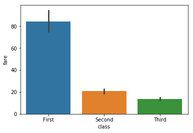

```python
# barplot of class vs fare
sns.barplot(x="class", y = 'fare', data=titanic)
```

Notice how `seaborn` magically computes the mean fares and generates the plot exactly as we want without us even specifying!

What if we wanted to look at the data more granularly and further *stratify* each `class` bar by the `sex` variable? Based on what you know about `seaborn` so far, how do you think we can do that?

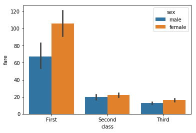

```python
# barplot of class vs fare stratified by sex
sns.barplot(x="class", y = 'fare', hue = "sex", data=titanic)
```

## Histograms

Histograms are used to visualize the *distribution* of a *continuous* variable.

Let’s say we wanted to see how the `age` was distributed across all passengers in our dataset. We can use the `distplot` function to generate our histogram.

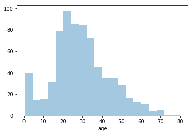

```python
# histogram of age
sns.distplot(titanic['age'].dropna(), kde=False)
```

We can change the number of bins used to plot our histogram to change the *granularity* of our distribution plot.

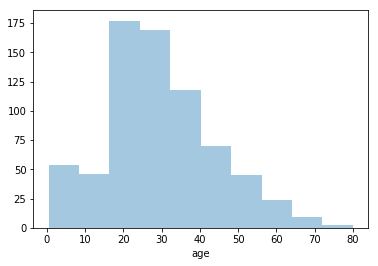

```python
# histogram of age
sns.distplot(titanic['age'].dropna(), kde=False, bins=10)
```

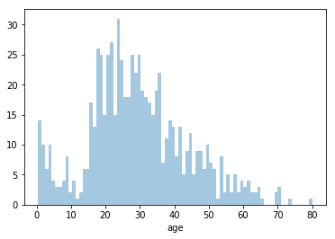

```python
# histogram of age
sns.distplot(titanic['age'].dropna(), kde=False, bins=80)
```

Unfortunately we can’t color our histograms by another variable, but we can compare the distributions of certain variables between *subsets* of our DataFrame by *layering* them.

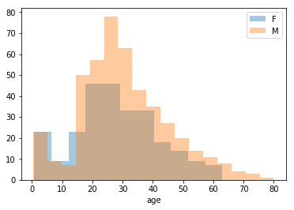

```python
# histogram of age for females
sns.distplot(titanic.query('sex == "female"')['age'].dropna(), kde=False, label="F")
sns.distplot(titanic.query('sex == "male"')['age'].dropna(), kde=False, label="M")
plt.legend()
```

## Count Plots

Count plots can be thought of as histograms for categorical variables.

Let’s say we wanted to visualize how many passengers there were in each `class`.

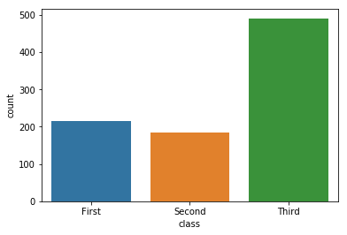

```python
# count plot of class
sns.countplot(x="class", data=titanic)
```

Now, let’s stratify each class by the `sex` variable using color. By now you’re an expert in this!

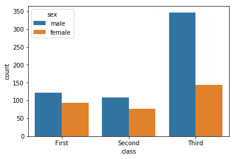

```python
# stratify class by sex variable
sns.countplot(x="class", hue = "sex",  data=titanic)
```

As always we can change the color palette:

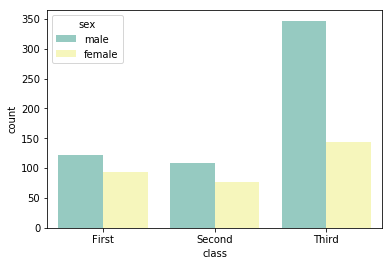

```python
# change color palette
sns.countplot(x="class", hue = "sex", palette = "Set3", data=titanic)
```

In this lesson you learned: * How to create barplots in seaborn * How to stratify barplots by another variable using color (`hue`) * How to create histograms in seaborn * Changing the granularity of the histograms (`bins`) * How to create count plots in seaborn * How to stratify count plots by another variable using color (`hue`)